# Segments, disks, spheres, and onward

Daniel Kaplan

This can easily be translated into $y$ as a function of $x$ (and $r$):
$$y(x) \equiv r \sqrt{1 - \frac{x^2}{r^2}} = \sqrt{r^2 - x^2}$$
This function produces only the top half of the circle.

To find the area of a disk of radius $r$ (yes, we remember the answer as well as you: $A_2 = \pi r^2$) we can use the slice-and-sum technique of differentials. Here, each differential will be a vertical line segment connecting the top and bottom halves of the circle. The segment at position $x$ has length $2 y(x)$. Adding up all the segments from the minute one at $x=-r$ to the longest one at $x=0$ to the minute one at $x=r$ is simple:
$$A_2 = \int_{-r}^{r} 2 y(x) dx = \int_{-r}^{r} 2 \sqrt{r^2 - x^2} dx$$

The author looked at that integral, checked whether the integrand (that is, the function inside the $\int$ sign) is a basic modeling function (no), guessed whether substitution might work (Best guess is $u = x^2/r^2$, but that gets us nowhere.), and peeked into the possibility of integration by parts (the integrand isn’t a product of two functions, so that’s going nowhere).

What next? The author happens to have a little book from 1899 called *A Short Table of Integrals*:

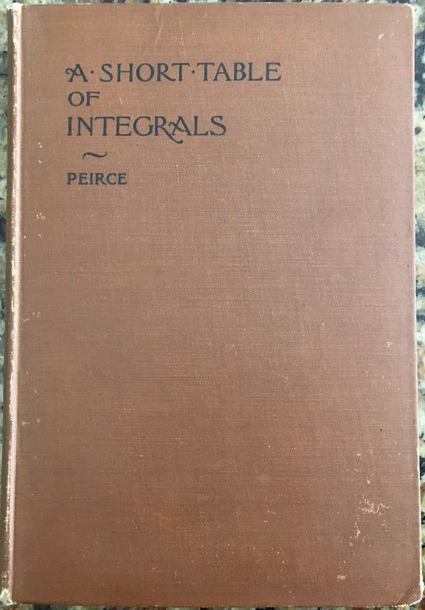

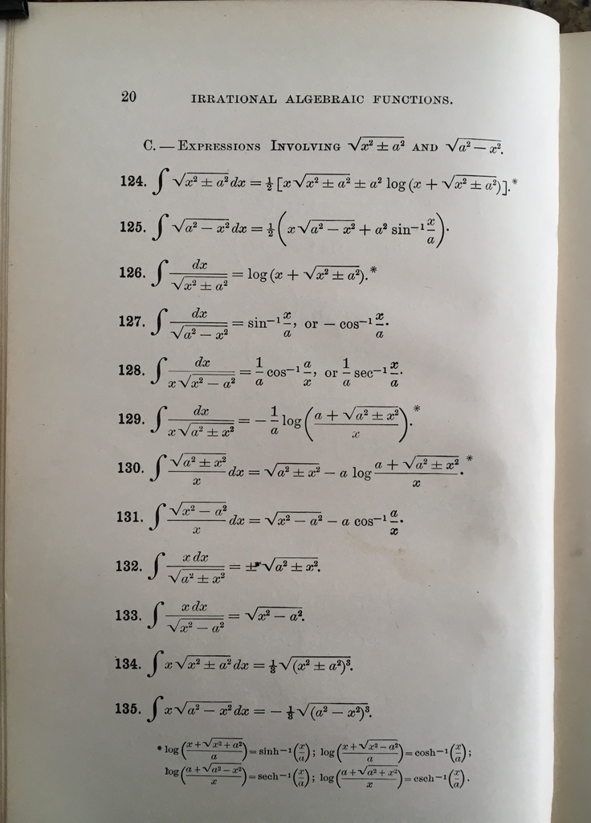

Paging through this, the author came across #125, which, to him, looked a lot like the present problem, but with the symbol $a$ instead of $r$.

Onto another slicing job … Now that we know the area of a disk of radius $r$, we can slice up the *sphere* into disks. The radius of each disk depends on the $x$ position it is located: $r(x) = r \sqrt{1 - \frac{x^2}{r^2}}$. Plug this into the formula for the area of a disk of radius $r$ and sum up over all the disks:
$$A_3 = \int_{-r}^{r} \pi \left[r \sqrt{1 - \frac{x^2}{r^2}}\right]^2 dx =
\int_{-r}^r \pi \left[r^2 - x^2\right]dx$$
The integrand is a linear combination of a constant function and $x^2$. These are basic modeling function so we can find the anti-derivative easily:
$$A_3 = \pi r^2 x\left.\right|_{-r}^{+r} - \frac{\pi}{3} x^3\left.\right|_{-r}^{+r} = \\
2 \pi r^3 - \frac{2}{3}\pi r^3 = \frac{4}{3}\pi r^3$$

What we’ve seen is a process for calculating the volume $A_n$ of a disk/ball of dimension $n$. We 1. take the formula for the volume $A_{n-1}$ of the disk/ball in a lower dimension, 2. plug in for $r$ the function $\sqrt{r^2 - x^2}$, and integrate over $x$ from $-r$ to $r$.

So, the volume of a 4-dimensional ball:
$$A_4 = \int_{-r}^r \frac{4}{3}\pi \left[\sqrt{r^2 - x^2}\right]^3 dx$$
We find the integrand as #137 in the *Table of Integrals*

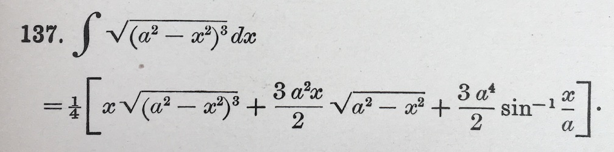